# ABCD SL Analysis

Zhenghan Qi

July 24, 2020

# Compute RT for VSL

- two groups are not different in target detection d-prime
- the DD group showed a significantly negative RT slope
- the TYP group showed a nonsignificantly negative RT slope
- Test the group difference in VSL

```
##
##  Wilcoxon rank sum test with continuity correction
##
## data:  dprime by group
## W = 174.5, p-value = 0.5461
## alternative hypothesis: true location shift is not equal to 0
##
##
##  Wilcoxon rank sum test
##
## data:  mean_rt by group
## W = 157, p-value = 0.3022
## alternative hypothesis: true location shift is not equal to 0
##
##
##  One Sample t-test
##
## data:  subj_table$rt_slope[subj_table$group == "DD"]
## t = -2.6421, df = 16, p-value = 0.008877
## alternative hypothesis: true mean is less than 0
## 95 percent confidence interval:
##        -Inf -0.9116466
## sample estimates:
## mean of x
## -2.687647
##
##
##  One Sample t-test
##
## data:  subj_table$rt_slope[subj_table$group == "TYP"]
## t = -0.83727, df = 22, p-value = 0.2057
## alternative hypothesis: true mean is less than 0
## 95 percent confidence interval:
##       -Inf 0.5534928
## sample estimates:
##  mean of x
## -0.5266957
```

- VSL RT summary stats (mean +/ sd)

```
## # A tibble: 2 x 5
##   group count rt                    slope               d_prime
##   <chr> <int> <chr>                 <chr>               <chr>
## 1 DD       17 "475.36 $\\pm$ 70.75" "-2.69 $\\pm$ 4.19" "6.57 $\\pm$ 2.30"
## 2 TYP      23 "491.24 $\\pm$ 70.15" "-0.53 $\\pm$ 3.02" "7.44 $\\pm$ 1.63"
```

- The DD group had a faster RT acceleration than the TYP group tested by linear regression models

```
##
## Call:
## lm(formula = rt_col ~ reindex * group_cond, data = fam_trial_vsl)
##
## Residuals:
##     Min      1Q  Median      3Q     Max
## -955.47  -61.12    3.55   67.06  312.66
##
## Coefficients:
##                       Estimate Std. Error t value Pr(>|t|)
## (Intercept)           509.8174    11.3636  44.864  < 2e-16 ***
## reindex                -3.0266     0.8014  -3.777 0.000169 ***
## group_condTYP         -11.3419    14.9059  -0.761 0.446907
## reindex:group_condTYP   2.4915     1.0492   2.375 0.017764 *
## ---
## Signif. codes:  0 '***' 0.001 '**' 0.01 '*' 0.05 '.' 0.1 ' ' 1
##
## Residual standard error: 109.3 on 933 degrees of freedom
## Multiple R-squared:  0.02318,    Adjusted R-squared:  0.02004
## F-statistic: 7.381 on 3 and 933 DF,  p-value: 6.86e-05
```

```
##
## Call:
## lm(formula = rt_col ~ reindex * group_cond, data = fam_trial_vsl_scale)
##
## Residuals:
##     Min      1Q  Median      3Q     Max
## -4.4363 -0.6037 -0.0520  0.5850  3.6945
##
## Coefficients:
##                        Estimate Std. Error t value Pr(>|t|)
## (Intercept)            0.294333   0.101298   2.906  0.00375 **
## reindex               -0.023750   0.007144  -3.325  0.00092 ***
## group_condTYP         -0.273308   0.132874  -2.057  0.03997 *
## reindex:group_condTYP  0.022062   0.009353   2.359  0.01853 *
## ---
## Signif. codes:  0 '***' 0.001 '**' 0.01 '*' 0.05 '.' 0.1 ' ' 1
##
## Residual standard error: 0.9747 on 933 degrees of freedom
## Multiple R-squared:  0.01179,    Adjusted R-squared:  0.008613
## F-statistic: 3.711 on 3 and 933 DF,  p-value: 0.01134
```

- marginal results with the raw RT data and significant results (same as linear regression) with the scaled data tested by lmer.

```
## Linear mixed model fit by REML. t-tests use Satterthwaite's method [
## lmerModLmerTest]
## Formula: rt_col ~ group_cond * reindex + (1 | id) + (0 + reindex | id)
##    Data: fam_trial_vsl
##
## REML criterion at convergence: 11110.8
##
## Scaled residuals:
##     Min      1Q  Median      3Q     Max
## -9.7061 -0.4878 -0.0532  0.5078  3.9472
##
## Random effects:
##  Groups   Name        Variance Std.Dev.
##  id       (Intercept) 3229.282 56.827
##  id.1     reindex        7.157  2.675
##  Residual             7345.982 85.709
## Number of obs: 937, groups:  id, 40
##
## Fixed effects:
##                       Estimate Std. Error       df t value Pr(>|t|)
## (Intercept)           509.3485    16.4184  46.2600  31.023  < 2e-16 ***
## group_condTYP         -11.2609    21.6141  45.9500  -0.521  0.60487
## reindex                -2.7352     0.9047  46.3700  -3.023  0.00406 **
## group_condTYP:reindex   2.1924     1.1882  45.7100   1.845  0.07150 .
## ---
## Signif. codes:  0 '***' 0.001 '**' 0.01 '*' 0.05 '.' 0.1 ' ' 1
##
## Correlation of Fixed Effects:
##             (Intr) gr_TYP reindx
## grop_cndTYP -0.760
## reindex     -0.331  0.251
## grp_cndTYP:  0.252 -0.328 -0.761
```

```
## Linear mixed model fit by REML. t-tests use Satterthwaite's method [
## lmerModLmerTest]
## Formula: rt_col ~ group_cond * reindex + (1 | id) + (0 + reindex | id)
##    Data: fam_trial_vsl_scale
##
## REML criterion at convergence: 2632.2
##
## Scaled residuals:
##     Min      1Q  Median      3Q     Max
## -4.5513 -0.6194 -0.0533  0.6002  3.7903
##
## Random effects:
##  Groups   Name        Variance Std.Dev.
##  id       (Intercept) 0.0000   0.0000
##  id.1     reindex     0.0000   0.0000
##  Residual             0.9501   0.9747
## Number of obs: 937, groups:  id, 40
##
## Fixed effects:
##                         Estimate Std. Error         df t value Pr(>|t|)
## (Intercept)             0.294333   0.101298 933.000000   2.906  0.00375
## group_condTYP          -0.273308   0.132874 933.000000  -2.057  0.03997
## reindex                -0.023750   0.007144 933.000000  -3.325  0.00092
## group_condTYP:reindex   0.022062   0.009353 933.000000   2.359  0.01853
##
## (Intercept)           **
## group_condTYP         *
## reindex               ***
## group_condTYP:reindex *
## ---
## Signif. codes:  0 '***' 0.001 '**' 0.01 '*' 0.05 '.' 0.1 ' ' 1
##
## Correlation of Fixed Effects:
##             (Intr) gr_TYP reindx
## grop_cndTYP -0.762
## reindex     -0.874  0.666
## grp_cndTYP:  0.668 -0.874 -0.764
```

## Plot of VSL RT

### RT as the function of Target repetition

```
##     reindex      group_cond    mean_RT          sd_RT
##  Min.   : 1.00   DD :24     Min.   :429.6   Min.   : 65.32
##  1st Qu.: 6.75   TYP:24     1st Qu.:469.5   1st Qu.: 87.90
##  Median :12.50              Median :482.4   Median :102.38
##  Mean   :12.50              Mean   :481.8   Mean   :107.31
##  3rd Qu.:18.25              3rd Qu.:502.8   3rd Qu.:120.30
##  Max.   :24.00              Max.   :527.5   Max.   :252.06
##      length            se
##  Min.   :14.00   Min.   :15.02
##  1st Qu.:16.75   1st Qu.:19.32
##  Median :19.00   Median :21.86
##  Mean   :19.52   Mean   :24.65
##  3rd Qu.:23.00   3rd Qu.:27.33
##  Max.   :23.00   Max.   :61.13
```

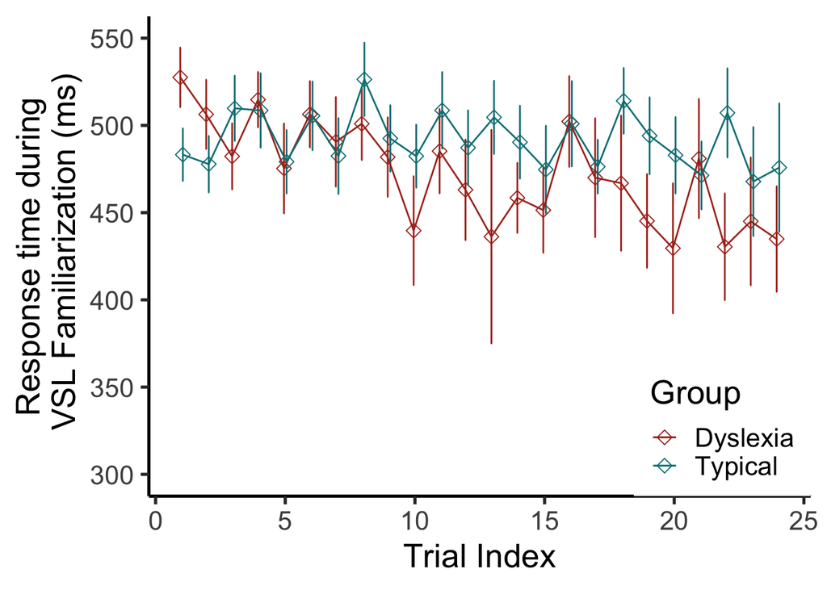

### plot mean RT slope across the two groups

- mean RT slope

```
## No summary function supplied, defaulting to `mean_se()`
```

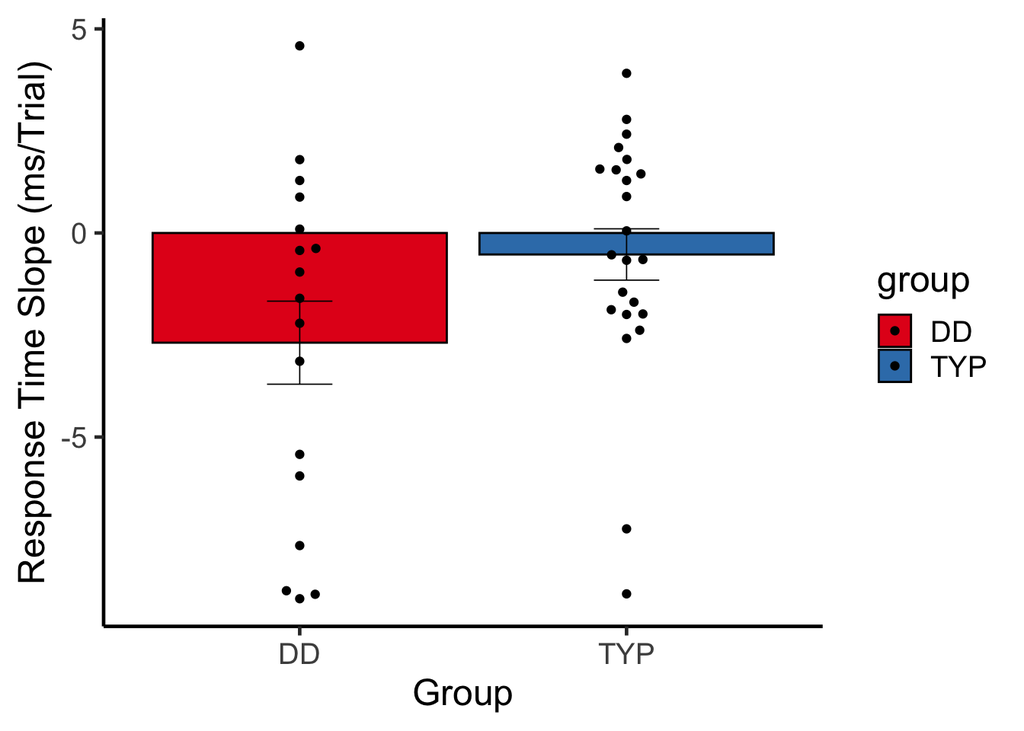

- mean RT slope scaled

```
## No summary function supplied, defaulting to `mean_se()`
```

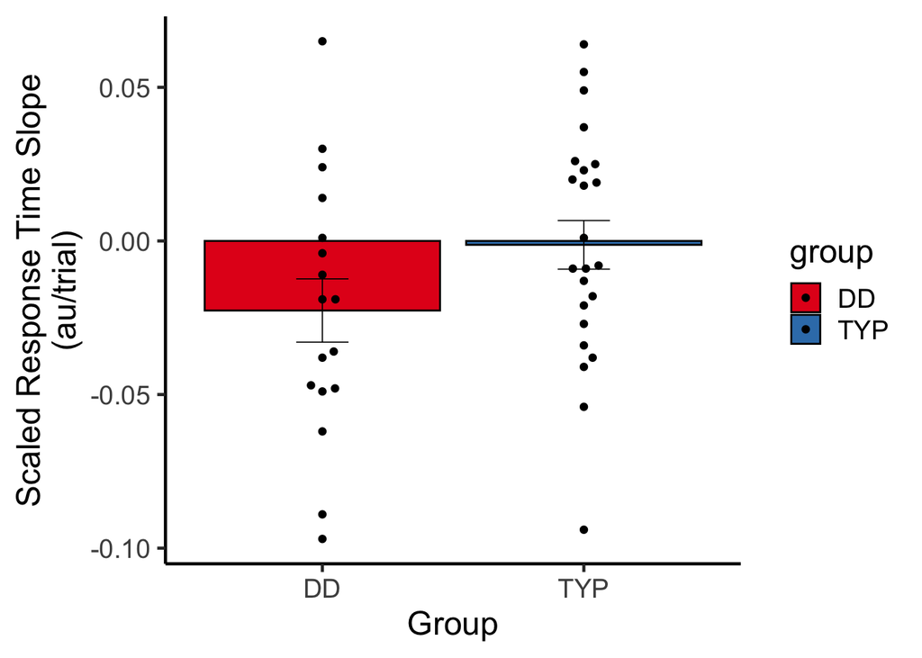

# Compute RT for TSL

- The two groups are not different in the target detection task
- Neither group showed a significant negative RT slope.

```
##
##  Wilcoxon rank sum test
##
## data:  dprime by group
## W = 173, p-value = 0.6135
## alternative hypothesis: true location shift is not equal to 0
##
##
##  Wilcoxon rank sum test
##
## data:  mean_rt by group
## W = 231, p-value = 0.2915
## alternative hypothesis: true location shift is not equal to 0
##
##
##  One Sample t-test
##
## data:  subj_table$rt_slope[subj_table$group == "DD"]
## t = -0.40501, df = 15, p-value = 0.3456
## alternative hypothesis: true mean is less than 0
## 95 percent confidence interval:
##      -Inf 1.896363
## sample estimates:
## mean of x
##  -0.56975
##
##
##  One Sample t-test
##
## data:  subj_table$rt_slope[subj_table$group == "TYP"]
## t = 1.2279, df = 23, p-value = 0.8841
## alternative hypothesis: true mean is less than 0
## 95 percent confidence interval:
##      -Inf 5.079512
## sample estimates:
## mean of x
##  2.120208
```

- TSL RT summary (mean +/- sd)

```
## # A tibble: 2 x 6
##   group count rt                slope          d_prime        hits
##   <chr> <int> <chr>             <chr>          <chr>          <chr>
## 1 DD       16 "400.34 $\\pm$ 1… "-0.57 $\\pm$… "1.07 $\\pm$ … "0.51 $\\pm$…
## 2 TYP      24 "372.78 $\\pm$ 8… "2.12 $\\pm$ … "1.28 $\\pm$ … "0.54 $\\pm$…
```

- remove outliers who have hit rate lower than and equal to 0.25 (remaining participant: 14 DD and 18 TYP)
- participants removed from analysis: ABCD_1705 ABCD_1720 ABCD_1747 ABCD_1767 ABCD_1783 ABCD_1788 ABCD_1709 ABCD_1724

```
## # A tibble: 2 x 6
##   group count rt                slope          d_prime        hits
##   <chr> <int> <chr>             <chr>          <chr>          <chr>
## 1 DD       14 "408.55 $\\pm$ 1… "-0.52 $\\pm$… "1.15 $\\pm$ … "0.55 $\\pm$…
## 2 TYP      18 "356.03 $\\pm$ 8… "0.12 $\\pm$ … "1.56 $\\pm$ … "0.66 $\\pm$…
```

- the two groups are not different in RT slope.

```
##
##  Welch Two Sample t-test
##
## data:  dprime by group
## t = -1.5595, df = 29.993, p-value = 0.1294
## alternative hypothesis: true difference in means is not equal to 0
## 95 percent confidence interval:
##  -0.9410684  0.1261565
## sample estimates:
##  mean in group DD mean in group TYP
##          1.152703          1.560159
```

```
##
##  Welch Two Sample t-test
##
## data:  rt_slope by group
## t = -0.34509, df = 29.433, p-value = 0.7325
## alternative hypothesis: true difference in means is not equal to 0
## 95 percent confidence interval:
##  -4.428877  3.149384
## sample estimates:
##  mean in group DD mean in group TYP
##        -0.5178571         0.1218889
```

```
##
## Call:
## lm(formula = rt_col ~ reindex * group_cond, data = fam_trial_tsl_usable)
##
## Residuals:
##     Min      1Q  Median      3Q     Max
## -518.45 -206.05   -9.07  233.37  582.65
##
## Coefficients:
##                       Estimate Std. Error t value Pr(>|t|)
## (Intercept)           416.3073    27.5729  15.098   <2e-16 ***
## reindex                 0.1412     0.9726   0.145    0.885
## group_condTYP         -53.7814    35.3733  -1.520    0.129
## reindex:group_condTYP  -0.2229     1.2596  -0.177    0.860
## ---
## Signif. codes:  0 '***' 0.001 '**' 0.01 '*' 0.05 '.' 0.1 ' ' 1
##
## Residual standard error: 265.7 on 941 degrees of freedom
## Multiple R-squared:  0.0118, Adjusted R-squared:  0.008652
## F-statistic: 3.746 on 3 and 941 DF,  p-value: 0.0108
```

```
##
## Call:
## lm(formula = rt_col ~ reindex * group_cond, data = fam_trial_tsl_usable_s)
##
## Residuals:
##     Min      1Q  Median      3Q     Max
## -2.2128 -0.7757 -0.2198  0.7533  3.2618
##
## Coefficients:
##                        Estimate Std. Error t value Pr(>|t|)
## (Intercept)            0.054084   0.102180   0.529    0.597
## reindex               -0.002201   0.003604  -0.611    0.541
## group_condTYP         -0.065300   0.131087  -0.498    0.619
## reindex:group_condTYP  0.002670   0.004668   0.572    0.568
##
## Residual standard error: 0.9848 on 941 degrees of freedom
## Multiple R-squared:  0.0004228,  Adjusted R-squared:  -0.002764
## F-statistic: 0.1327 on 3 and 941 DF,  p-value: 0.9406
```

```
## Linear mixed model fit by REML. t-tests use Satterthwaite's method [
## lmerModLmerTest]
## Formula: rt_col ~ reindex * group_cond + (1 | id) + (0 + reindex | id)
##    Data: fam_trial_tsl_usable
##
## REML criterion at convergence: 13150
##
## Scaled residuals:
##     Min      1Q  Median      3Q     Max
## -2.1923 -0.7006 -0.1916  0.6837  2.6744
##
## Random effects:
##  Groups   Name        Variance  Std.Dev.
##  id       (Intercept)  6440.088  80.250
##  id.1     reindex         5.037   2.244
##  Residual             62185.466 249.370
## Number of obs: 945, groups:  id, 32
##
## Fixed effects:
##                       Estimate Std. Error       df t value Pr(>|t|)
## (Intercept)           415.7086    33.9423  66.3100  12.247   <2e-16 ***
## reindex                -0.1611     1.1227  64.0100  -0.143    0.886
## group_condTYP         -57.8631    44.3086  60.4700  -1.306    0.197
## reindex:group_condTYP   0.1428     1.4586  59.4200   0.098    0.922
## ---
## Signif. codes:  0 '***' 0.001 '**' 0.01 '*' 0.05 '.' 0.1 ' ' 1
##
## Correlation of Fixed Effects:
##             (Intr) reindx gr_TYP
## reindex     -0.559
## grop_cndTYP -0.766  0.428
## rndx:gr_TYP  0.430 -0.770 -0.545
```

```
## Linear mixed model fit by REML. t-tests use Satterthwaite's method [
## lmerModLmerTest]
## Formula: rt_col ~ reindex * group_cond + (1 | id) + (0 + reindex | id)
##    Data: fam_trial_tsl_usable_s
##
## REML criterion at convergence: 2676.7
##
## Scaled residuals:
##     Min      1Q  Median      3Q     Max
## -2.2469 -0.7877 -0.2232  0.7649  3.3122
##
## Random effects:
##  Groups   Name        Variance Std.Dev.
##  id       (Intercept) 0.0000   0.0000
##  id.1     reindex     0.0000   0.0000
##  Residual             0.9698   0.9848
## Number of obs: 945, groups:  id, 32
##
## Fixed effects:
##                         Estimate Std. Error         df t value Pr(>|t|)
## (Intercept)             0.054084   0.102180 941.000000   0.529    0.597
## reindex                -0.002201   0.003604 941.000000  -0.611    0.541
## group_condTYP          -0.065300   0.131087 941.000000  -0.498    0.619
## reindex:group_condTYP   0.002670   0.004668 941.000000   0.572    0.568
##
## Correlation of Fixed Effects:
##             (Intr) reindx gr_TYP
## reindex     -0.867
## grop_cndTYP -0.779  0.675
## rndx:gr_TYP  0.669 -0.772 -0.866
```

## Plot of TSL RT

### RT as the function of Target repetition

```
##     reindex      group_cond    mean_RT          sd_RT           length
##  Min.   : 1.00   DD :48     Min.   :180.5   Min.   :132.7   Min.   : 5.0
##  1st Qu.:12.75   TYP:48     1st Qu.:340.3   1st Qu.:230.2   1st Qu.: 8.0
##  Median :24.50              Median :383.8   Median :267.1   Median :11.0
##  Mean   :24.50              Mean   :390.3   Mean   :262.4   Mean   :10.5
##  3rd Qu.:36.25              3rd Qu.:450.8   3rd Qu.:297.6   3rd Qu.:13.0
##  Max.   :48.00              Max.   :666.1   Max.   :378.5   Max.   :18.0
##        se
##  Min.   : 41.97
##  1st Qu.: 69.21
##  Median : 81.42
##  Mean   : 84.03
##  3rd Qu.: 96.09
##  Max.   :154.50
```

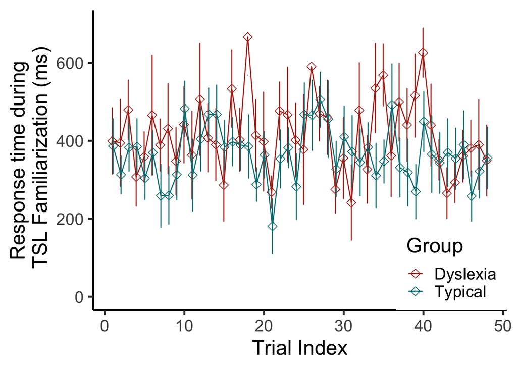

### plot mean RT slope across the two groups * mean RT slope

```
## No summary function supplied, defaulting to `mean_se()`
```

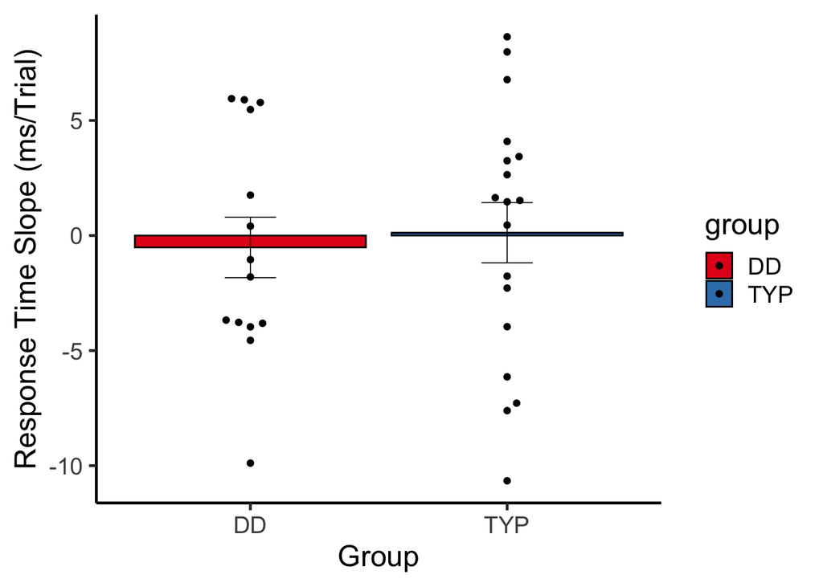

- mean RT slope scaled

```
## No summary function supplied, defaulting to `mean_se()`
```

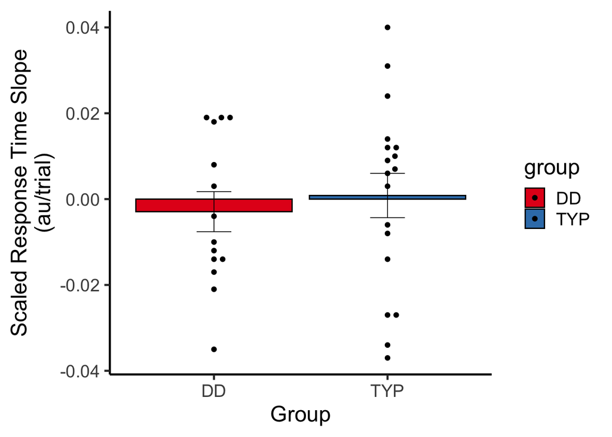

## Combine slope data of both tasks

### check interactions between task and group, using scaled RT: No interaction; anova showed marginal main effect of group (TYP is slower)

```
##
## Error: subj
##           Df   Sum Sq   Mean Sq F value Pr(>F)
## group      1 0.002526 0.0025258   2.681  0.112
## Residuals 29 0.027323 0.0009422
##
## Error: subj:task
##            Df  Sum Sq  Mean Sq F value Pr(>F)
## task        1 0.00243 0.002428   1.833  0.186
## task:group  1 0.00103 0.001030   0.778  0.385
## Residuals  29 0.03841 0.001324
```

```
## Linear mixed model fit by REML. t-tests use Satterthwaite's method [
## lmerModLmerTest]
## Formula: rt_col ~ task * group_cond + (1 + task | id) + (1 | reindex)
##    Data: all_fam_trials
##
## REML criterion at convergence: 5283.5
##
## Scaled residuals:
##     Min      1Q  Median      3Q     Max
## -4.5299 -0.7082 -0.1188  0.6724  3.7965
##
## Random effects:
##  Groups   Name        Variance  Std.Dev.  Corr
##  reindex  (Intercept) 5.895e-03 7.678e-02
##  id       (Intercept) 0.000e+00 0.000e+00
##           taskVisual  1.583e-17 3.979e-09  NaN
##  Residual             9.581e-01 9.788e-01
## Number of obs: 1882, groups:  reindex, 48; id, 41
##
## Fixed effects:
##                            Estimate Std. Error         df t value Pr(>|t|)
## (Intercept)              -1.602e-04  5.193e-02  6.381e+02  -0.003    0.998
## taskVisual                2.496e-03  7.160e-02  1.508e+03   0.035    0.972
## group_condTYP             3.455e-04  6.520e-02  1.859e+03   0.005    0.996
## taskVisual:group_condTYP -1.683e-04  9.195e-02  1.849e+03  -0.002    0.999
##
## Correlation of Fixed Effects:
##             (Intr) tskVsl gr_TYP
## taskVisual  -0.692
## grop_cndTYP -0.760  0.552
## tskVsl:_TYP  0.539 -0.763 -0.709
```

- plot both tasks (scaled RT)

```
## No summary function supplied, defaulting to `mean_se()`
## No summary function supplied, defaulting to `mean_se()`
```

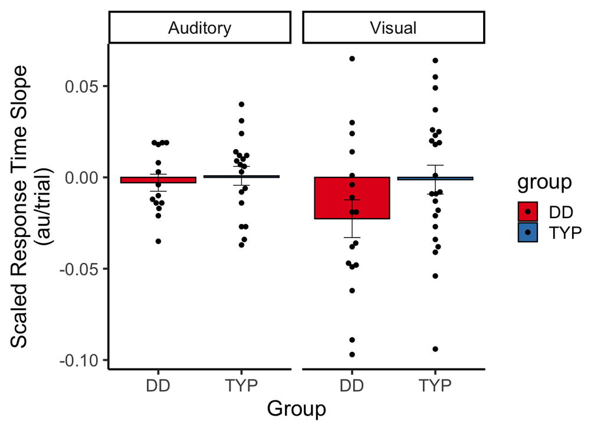

# Compute accuracy

## Accuracy Data Summary (mean +/- sd)

```
## # A tibble: 4 x 4
## # Groups:   group [2]
##   group    task     count accuracy
##   <chr>    <chr>    <int> <chr>
## 1 Dyslexic Auditory    16 "0.55 $\\pm$ 0.09"
## 2 Dyslexic Visual      17 "0.72 $\\pm$ 0.21"
## 3 Typical  Auditory    24 "0.66 $\\pm$ 0.13"
## 4 Typical  Visual      23 "0.67 $\\pm$ 0.23"
```

## Look into group performance between Dyl and Typ

### simple t test: both groups performed above chance for both tasks

```
##
##  One Sample t-test
##
## data:  DD_acc_vsl
## t = 4.3948, df = 16, p-value = 0.0002261
## alternative hypothesis: true mean is greater than 0.5
## 95 percent confidence interval:
##  0.6329919       Inf
## sample estimates:
## mean of x
## 0.7206471
```

```
##
##  One Sample t-test
##
## data:  DD_acc_tsl
## t = 2.1928, df = 15, p-value = 0.02225
## alternative hypothesis: true mean is greater than 0.5
## 95 percent confidence interval:
##  0.5097758       Inf
## sample estimates:
## mean of x
##   0.54875
```

```
##
##  One Sample t-test
##
## data:  TYP_acc_vsl
## t = 3.5474, df = 22, p-value = 0.0009032
## alternative hypothesis: true mean is greater than 0.5
## 95 percent confidence interval:
##  0.5883823       Inf
## sample estimates:
## mean of x
## 0.6713043
```

```
##
##  One Sample t-test
##
## data:  TYP_acc_tsl
## t = 6.2175, df = 23, p-value = 1.208e-06
## alternative hypothesis: true mean is greater than 0.5
## 95 percent confidence interval:
##  0.616952      Inf
## sample estimates:
## mean of x
## 0.6614583
```

### anova: marginal main effect of task and marginal interaction between task and group

```
##
## Error: subj
##           Df Sum Sq Mean Sq F value Pr(>F)
## group      1 0.0222 0.02218   0.754  0.391
## Residuals 37 1.0889 0.02943
##
## Error: subj:task
##            Df Sum Sq Mean Sq F value Pr(>F)
## task        1 0.1086 0.10864   3.221 0.0809 .
## task:group  1 0.1088 0.10877   3.225 0.0807 .
## Residuals  37 1.2480 0.03373
## ---
## Signif. codes:  0 '***' 0.001 '**' 0.01 '*' 0.05 '.' 0.1 ' ' 1
```

### generalized linear effect modeling: main effect of task (visual > auditory); main effect of group (TYP > DD); marginal interaction between task and group

```
## Generalized linear mixed model fit by maximum likelihood (Laplace
##   Approximation) [glmerMod]
##  Family: binomial  ( logit )
## Formula: corr ~ task * group + (1 + task | subj) + (1 | trial)
##    Data: all_accuracy
##
##      AIC      BIC   logLik deviance df.resid
##   3091.9   3138.6  -1537.9   3075.9     2552
##
## Scaled residuals:
##     Min      1Q  Median      3Q     Max
## -3.8869 -1.0408  0.4311  0.7491  1.8645
##
## Random effects:
##  Groups Name        Variance Std.Dev. Corr
##  subj   (Intercept) 0.10879  0.3298
##         taskVisual  1.54476  1.2429   -0.38
##  trial  (Intercept) 0.02172  0.1474
## Number of obs: 2560, groups:  subj, 41; trial, 32
##
## Fixed effects:
##                     Estimate Std. Error z value Pr(>|z|)
## (Intercept)           0.2007     0.1248   1.608  0.10785
## taskVisual            1.0186     0.3365   3.027  0.00247 **
## groupTYP              0.4928     0.1597   3.086  0.00203 **
## taskVisual:groupTYP  -0.7947     0.4412  -1.801  0.07164 .
## ---
## Signif. codes:  0 '***' 0.001 '**' 0.01 '*' 0.05 '.' 0.1 ' ' 1
##
## Correlation of Fixed Effects:
##             (Intr) tskVsl grpTYP
## taskVisual  -0.418
## groupTYP    -0.746  0.327
## tskVsl:gTYP  0.319 -0.760 -0.427
```

## plot the accuracy by group and task

```
## No summary function supplied, defaulting to `mean_se()`
## No summary function supplied, defaulting to `mean_se()`
```

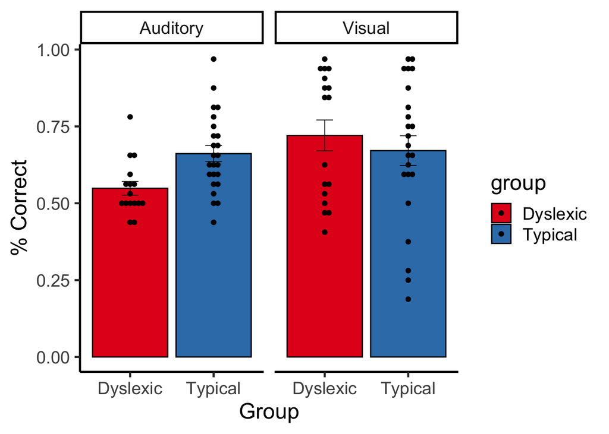

# A t-test to compare between Dylexia and Typical group

## In tsl

```
##
##  Welch Two Sample t-test
##
## data:  DD_acc_tsl and TYP_acc_tsl
## t = -3.297, df = 37.874, p-value = 0.00213
## alternative hypothesis: true difference in means is not equal to 0
## 95 percent confidence interval:
##  -0.18192006 -0.04349661
## sample estimates:
## mean of x mean of y
## 0.5487500 0.6614583
```

## In vsl

```
##
##  Welch Two Sample t-test
##
## data:  DD_acc_vsl and TYP_acc_vsl
## t = 0.70832, df = 36.548, p-value = 0.4832
## alternative hypothesis: true difference in means is not equal to 0
## 95 percent confidence interval:
##  -0.09186351  0.19054893
## sample estimates:
## mean of x mean of y
## 0.7206471 0.6713043
```